# Proyecto

Autism disorder & Postmortem-> SRP132816 n_samples -> 65 Study Title -> Single-nucleus RNA sequencing of post-mortem brain tissue from Autism Spectrum Disorder patients

```r
library("recount3")
human_projects <- available_projects()
```

```
## 2021-02-28 16:43:08 caching file sra.recount_project.MD.gz.
```

```
## 2021-02-28 16:43:09 caching file gtex.recount_project.MD.gz.
```

```
## 2021-02-28 16:43:11 caching file tcga.recount_project.MD.gz.
```

```r
## 2021-02-25 05:12:42 caching file sra.recount_project.MD.gz.

## 2021-02-25 05:12:43 caching file gtex.recount_project.MD.gz.

## 2021-02-25 05:12:43 caching file tcga.recount_project.MD.gz.

rse_gene_SRP132816 <- create_rse(
    subset(
        human_projects,
        project == "SRP132816" & project_type == "data_sources"
    )
)
```

```
## 2021-02-28 16:43:20 downloading and reading the metadata.
```

```
## 2021-02-28 16:43:22 caching file sra.sra.SRP132816.MD.gz.
```

```
## 2021-02-28 16:43:23 caching file sra.recount_project.SRP132816.MD.gz.
```

```
## 2021-02-28 16:43:24 caching file sra.recount_qc.SRP132816.MD.gz.
```

```
## 2021-02-28 16:43:26 caching file sra.recount_seq_qc.SRP132816.MD.gz.
```

```
## 2021-02-28 16:43:27 caching file sra.recount_pred.SRP132816.MD.gz.
```

```
## 2021-02-28 16:43:30 downloading and reading the feature information.
```

```
## 2021-02-28 16:43:30 caching file human.gene_sums.G026.gtf.gz.
```

```
## 2021-02-28 16:43:32 downloading and reading the counts: 65 samples across 63856 features.
```

```
## 2021-02-28 16:43:34 caching file sra.gene_sums.SRP132816.G026.gz.
```

```
## 2021-02-28 16:43:36 construcing the RangedSummarizedExperiment (rse) object.
```

```r
assay(rse_gene_SRP132816, "counts") <- compute_read_counts(rse_gene_SRP132816)
```

```r
rse_gene_SRP132816$sra.sample_attributes[1:5]
```

```
## [1] "age;;44|biomaterial_provider;;NIH NeuroBioBank/University of Maryland Brain and Tissue Bank|BioSampleModel;;Human|disease;;Control|isolate;;5981|sex;;female|tissue;;Brain, prefrontal cortex"
## [2] "age;;34|biomaterial_provider;;NIH NeuroBioBank/University of Maryland Brain and Tissue Bank|BioSampleModel;;Human|disease;;Control|isolate;;5546|sex;;female|tissue;;Brain, prefrontal cortex"
## [3] "age;;21|biomaterial_provider;;NIH NeuroBioBank/University of Maryland Brain and Tissue Bank|BioSampleModel;;Human|disease;;Epilepsy|isolate;;5839|sex;;female|tissue;;Brain, prefrontal cortex"
## [4] "age;;19|biomaterial_provider;;NIH NeuroBioBank/University of Maryland Brain and Tissue Bank|BioSampleModel;;Human|disease;;Control|isolate;;5893|sex;;male|tissue;;Brain, prefrontal cortex"
## [5] "age;;46|biomaterial_provider;;NIH NeuroBioBank/University of Maryland Brain and Tissue Bank|BioSampleModel;;Human|disease;;Epilepsy|isolate;;5881|sex;;female|tissue;;Brain, prefrontal cortex"
```

```r
rse_gene_SRP132816 <- expand_sra_attributes(rse_gene_SRP132816)

colData(rse_gene_SRP132816)[
    ,
    grepl("^sra_attribute", colnames(colData(rse_gene_SRP132816)))
]
```

```
## DataFrame with 65 rows and 7 columns
##            sra_attribute.age sra_attribute.biomaterial_provider
##                  <character>                        <character>
## SRR9264382                44             NIH NeuroBioBank/Uni..
## SRR9264383                34             NIH NeuroBioBank/Uni..
## SRR9264384                21             NIH NeuroBioBank/Uni..
## SRR9264385                19             NIH NeuroBioBank/Uni..
## SRR9264386                46             NIH NeuroBioBank/Uni..
## ...                      ...                                ...
## SRR9262951                15             NIH NeuroBioBank/Uni..
## SRR9262953                11             NIH NeuroBioBank/Uni..
## SRR9262954                14             NIH NeuroBioBank/Uni..
## SRR9262955                13             NIH NeuroBioBank/Uni..
## SRR9262957                12             NIH NeuroBioBank/Uni..
##            sra_attribute.BioSampleModel sra_attribute.disease
##                             <character>           <character>
## SRR9264382                        Human               Control
## SRR9264383                        Human               Control
## SRR9264384                        Human              Epilepsy
## SRR9264385                        Human               Control
## SRR9264386                        Human              Epilepsy
## ...                                 ...                   ...
## SRR9262951                        Human                   ASD
## SRR9262953                        Human                   ASD
## SRR9262954                        Human                   ASD
## SRR9262955                        Human               Control
## SRR9262957                        Human                   ASD
##            sra_attribute.isolate sra_attribute.sex   sra_attribute.tissue
##                      <character>       <character>            <character>
## SRR9264382                  5981            female Brain, prefrontal co..
## SRR9264383                  5546            female Brain, prefrontal co..
## SRR9264384                  5839            female Brain, prefrontal co..
## SRR9264385                  5893              male Brain, prefrontal co..
## SRR9264386                  5881            female Brain, prefrontal co..
## ...                          ...               ...                    ...
## SRR9262951                  5531              male Brain, anterior cing..
## SRR9262953                  5978              male Brain, prefrontal co..
## SRR9262954                  6033            female Brain, prefrontal co..
## SRR9262955                  5554            female Brain, anterior cing..
## SRR9262957                  5565              male Brain, prefrontal co..
```

##Se van a arreglar los datos para poder interpretarlos correctamente de forma numerica. ## Pasar de character a numeric o factor

```r
rse_gene_SRP132816$sra_attribute.age <- as.numeric(rse_gene_SRP132816$sra_attribute.age)

rse_gene_SRP132816$sra_attribute.disease <- factor(rse_gene_SRP132816$sra_attribute.disease)

rse_gene_SRP132816$sra_attribute.sex <- factor(rse_gene_SRP132816$sra_attribute.sex)

rse_gene_SRP132816$sra_attribute.tissue <- factor(rse_gene_SRP132816$sra_attribute.tissue)

## Resumen de las variables de interés
summary(as.data.frame(colData(rse_gene_SRP132816)[
    ,
    grepl("^sra_attribute.[age|disease|sex|tissue]", colnames(colData(rse_gene_SRP132816)))
]))
```

```
##  sra_attribute.age sra_attribute.disease sra_attribute.isolate
##  Min.   : 4.00     ASD     :31           Length:65
##  1st Qu.:13.00     Control :31           Class :character
##  Median :15.00     Epilepsy: 3           Mode  :character
##  Mean   :16.58
##  3rd Qu.:20.00
##  Max.   :54.00
##  sra_attribute.sex                       sra_attribute.tissue
##  female:17         Brain, anterior cingulate cortex:28
##  male  :48         Brain, prefrontal cortex        :37
##
##
##
##
```

De las 65 muestras que se obtuvieron, 48 corresponden a hombres 17 a mujeres. El rango de edad promedio se situa en los 17 años, donde el/la menor del total tan solo tenía 4 años y el/la mayor tenía 54 años. 31 se tomaron como sujetos control, 31 eran sujetos con ASD y 3 con epilepsia. Las regiones del cerebro que se analizaron fueron la corteza cingulada anterior(28 sujetos) y la corteza prefrontal(37 sujetos).

```r
## Encontraremos diferencias entre muestras de menores de edad(<18) vs mayores de edad(>18)
rse_gene_SRP132816$menores <- factor(ifelse(rse_gene_SRP132816$sra_attribute.age < 18, "menores", "mayores"))
table(rse_gene_SRP132816$menores)
```

```
##
## mayores menores
##      24      41
```

La mayoría de los muestras corresponden a menores de edad <18. Un 63.1% son menores y el resto(36.9%)son mayores.

##gene_fc_count_all.total: Total number of fragments, including multi-mappers, input to featureCounts ##gene_fc_count_all.assigned: Number of fragments, including multi-mappers, assigned by featureCounts to a gene

Con estos se datos se harán figuras para mostrar la proporción de genes que se dan en algunas categorias.

```r
rse_gene_SRP132816$assigned_gene_prop <- rse_gene_SRP132816$recount_qc.gene_fc_count_all.assigned / rse_gene_SRP132816$recount_qc.gene_fc_count_all.total

summary(rse_gene_SRP132816$assigned_gene_prop)
```

```
##    Min. 1st Qu.  Median    Mean 3rd Qu.    Max.
##  0.2026  0.3251  0.6497  0.5402  0.7516  0.8271
```

Figura 1.A #Plot gene_prop vs age

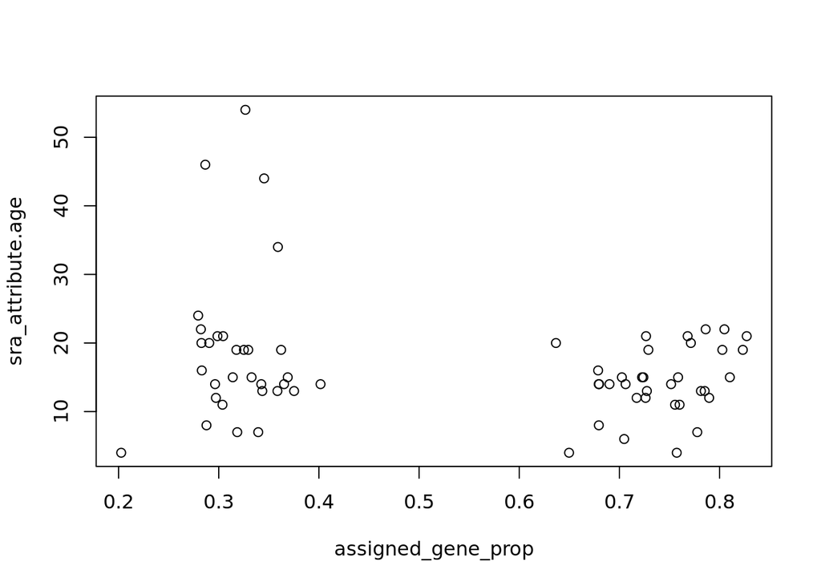

```r
with(colData(rse_gene_SRP132816), plot(assigned_gene_prop, sra_attribute.age))
```

En esta figura podemos visualizar que la mayoría de la proporción de los genes se distribuyen entre los sujetos de edad entre 10 y 25 años. Esto sencillamente se debe a que la mayoría de los sujetos control y con enfermedad se encuentran en este rango de edad.

```r
## ¿hay alguna diferencia entre los grupos de edad?
with(colData(rse_gene_SRP132816), tapply(assigned_gene_prop, menores, summary))
```

```
## $mayores
##    Min. 1st Qu.  Median    Mean 3rd Qu.    Max.
##  0.2795  0.3029  0.3522  0.5027  0.7689  0.8271
##
## $menores
##    Min. 1st Qu.  Median    Mean 3rd Qu.    Max.
##  0.2026  0.3424  0.6795  0.5621  0.7274  0.8103
```

Figura 1.B #Plot gene_prop vs disease

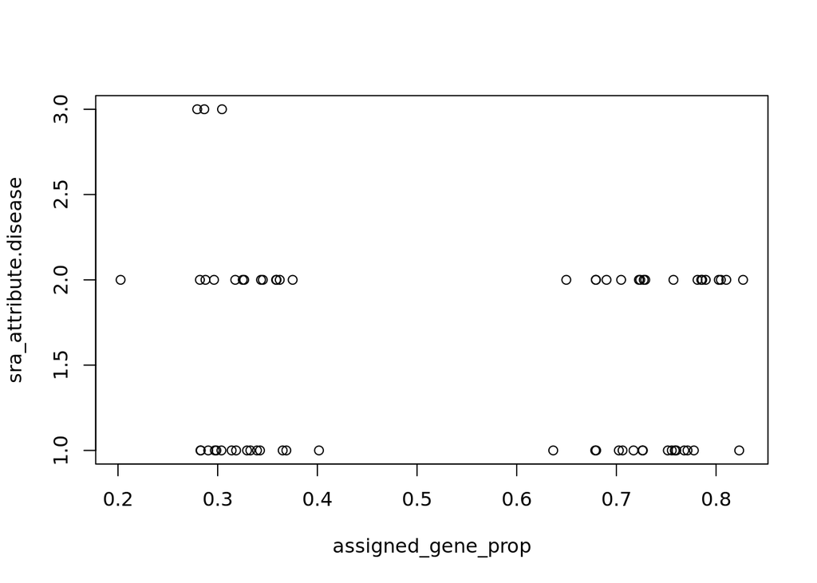

```r
with(colData(rse_gene_SRP132816), plot(assigned_gene_prop, sra_attribute.disease))
```

En esta figura podemos visualizar simplemente la proporción de genes que se distribuyen entre las 3 condiciones respecto a enfermedad: sano(grupo control), con (ASD) y con epilepsia. En la condición control y la de ASD es donde se distribuyen la mayoría de genes.

```r
## Guardemos nuestro objeto entero por si luego cambiamos de opinión
rse_gene_SRP132816_unfiltered <- rse_gene_SRP132816
```

Figura 2

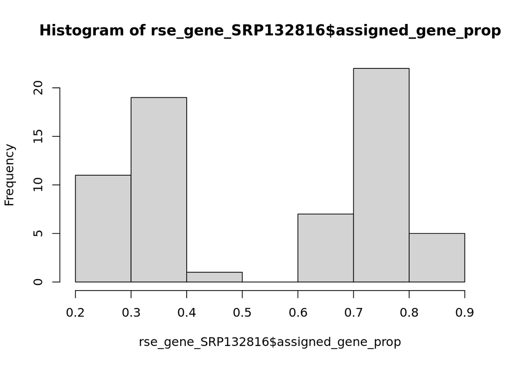

```r
## Se usa un histograma para poder visualizar y posteriormente eliminar a muestras malas.
hist(rse_gene_SRP132816$assigned_gene_prop)
```

En la Figura 2, podemos apreciar que el histograma entre el intervalo 0.4-0.6 la frecuencia es casi 0 en el intervalo 0.4-0.5 y 0 en el intervalo 0.5-0.6. Si lo comparamos con los demás rangos de intervalos, esta frecuencia es muy baja por lo que procederemos a eliminarla.

```r
table((rse_gene_SRP132816$assigned_gene_prop < 0.4)|(rse_gene_SRP132816$assigned_gene_prop > 0.6))
```

```
##
## FALSE  TRUE
##     1    64
```

Resulta que solo eliminamos a un paciente.

```r
rse_gene_SRP132816 <- rse_gene_SRP132816[, (rse_gene_SRP132816$assigned_gene_prop < 0.4)|(rse_gene_SRP132816$assigned_gene_prop > 0.6)]

## Calculemos los niveles medios de expresión de los genes en nuestras
## muestras.
## Ojo: en un análisis real probablemente haríamos esto con los RPKMs o CPMs
## en vez de las cuentas.
gene_means <- rowMeans(assay(rse_gene_SRP132816, "counts"))
summary(gene_means)
```

```
##    Min. 1st Qu.  Median    Mean 3rd Qu.    Max.
##       0       0       8    1003     234 4232806
```

```r
dim(rse_gene_SRP132816)
```

```
## [1] 63856    64
```

```r
dim(rse_gene_SRP132816_unfiltered)
```

```
## [1] 63856    65
```

```r
## Eliminamos genes
rse_gene_SRP132816 <- rse_gene_SRP132816[gene_means > 0.1, ]
##Dimensiones finales
dim(rse_gene_SRP132816)
```

```
## [1] 53217    64
```

```r
## Porcentaje de genes que retuvimos
round(nrow(rse_gene_SRP132816) / nrow(rse_gene_SRP132816_unfiltered) * 100, 2)
```

```
## [1] 83.34
```

#Normalizamos datos

```r
library(limma)
library("edgeR") # BiocManager::install("edgeR", update = FALSE)
dge <- DGEList(
    counts = assay(rse_gene_SRP132816, "counts"),
    genes = rowData(rse_gene_SRP132816)
)
dge <- calcNormFactors(dge)
```

#Expresiones diferenciales

Figura 3 Volvemos a visualizar una distribucion de los genes acorde a nuestros grupos(mayores y menores) en una grafica tipo boxplot y también vemos la distribución de genes acorde al tejido al que pertenecen.

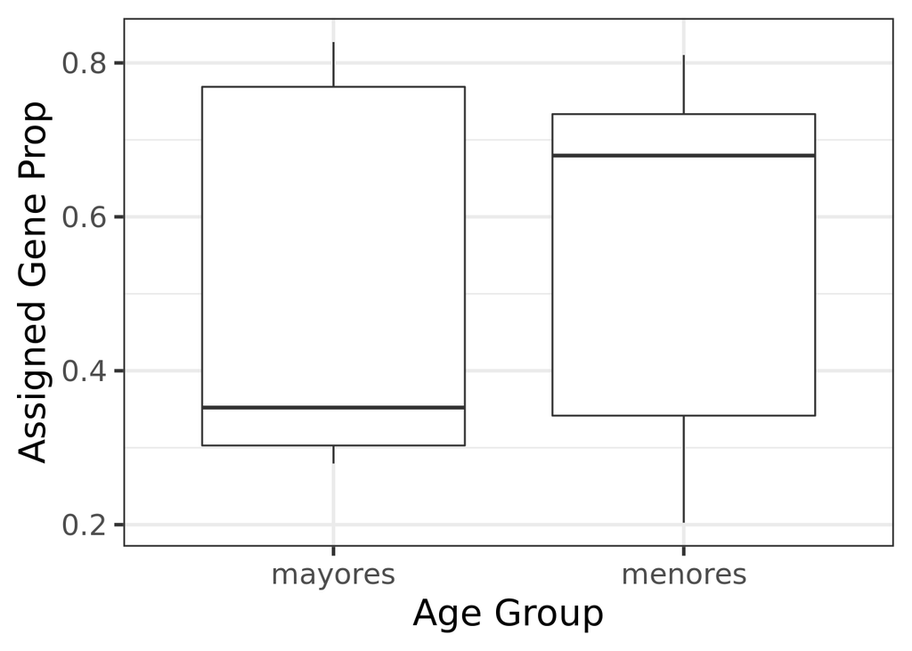

```r
library("ggplot2")
ggplot(as.data.frame(colData(rse_gene_SRP132816)), aes(y = assigned_gene_prop, x = menores)) +
    geom_boxplot() +
    theme_bw(base_size = 20) +
    ylab("Assigned Gene Prop") +
    xlab("Age Group")
```

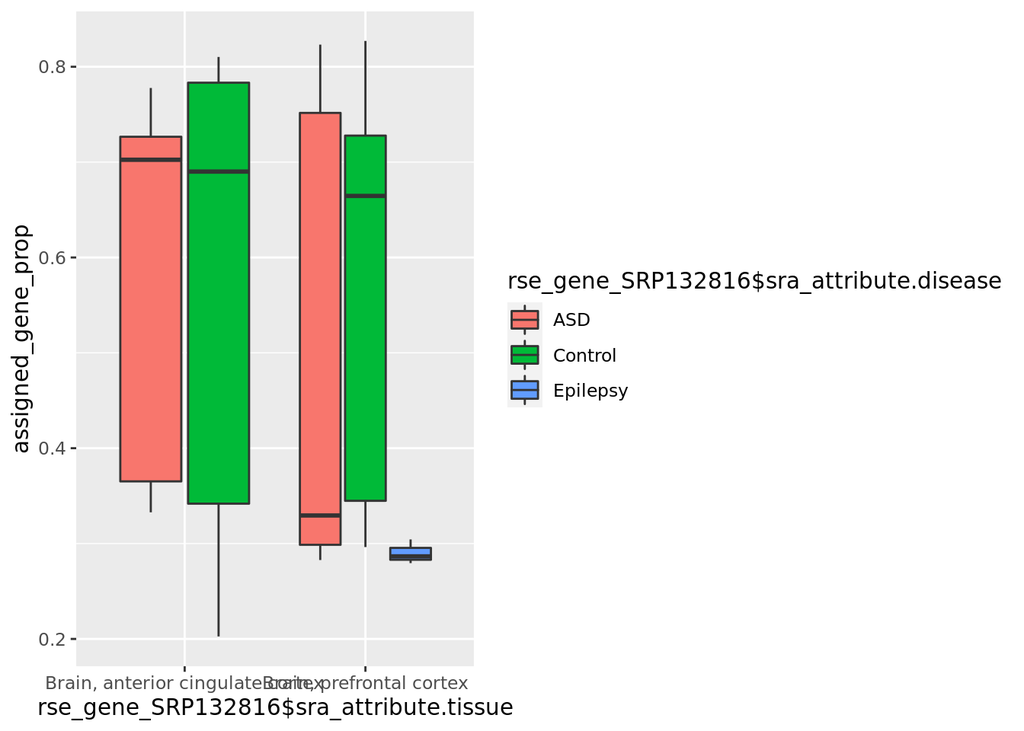

```r
ggplot(as.data.frame(colData(rse_gene_SRP132816)), aes(y = assigned_gene_prop, x = rse_gene_SRP132816$sra_attribute.tissue, fill = rse_gene_SRP132816$sra_attribute.disease)) +
    geom_boxplot()
```

```r
    #ylab("Assigned Gene Prop") + xlab("Tissue")
```

#Modelo estadístico

```r
mod <- model.matrix(~ menores + sra_attribute.disease + sra_attribute.sex + sra_attribute.tissue + assigned_gene_prop,
    data = colData(rse_gene_SRP132816)
)
colnames(mod)
```

```
## [1] "(Intercept)"
## [2] "menoresmenores"
## [3] "sra_attribute.diseaseControl"
## [4] "sra_attribute.diseaseEpilepsy"
## [5] "sra_attribute.sexmale"
## [6] "sra_attribute.tissueBrain, prefrontal cortex"
## [7] "assigned_gene_prop"
```

## Análisis de expresión diferencial

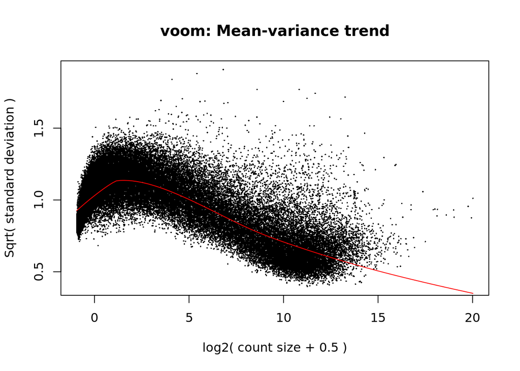

```r
library("limma")
vGene <- voom(dge, mod, plot = TRUE)
```

```r
eb_results <- eBayes(lmFit(vGene))

de_results <- topTable(
    eb_results,
    coef = 2,
    number = nrow(rse_gene_SRP132816),
    sort.by = "none"
)
dim(de_results)
```

```
## [1] 53217    16
```

```r
head(de_results)
```

```
##                    source type score phase           gene_id
## ENSG00000223972.5  HAVANA gene  1735    NA ENSG00000223972.5
## ENSG00000278267.1 ENSEMBL gene    68    NA ENSG00000278267.1
## ENSG00000227232.5  HAVANA gene  1351    NA ENSG00000227232.5
## ENSG00000284332.1 ENSEMBL gene   138    NA ENSG00000284332.1
## ENSG00000243485.5  HAVANA gene  1021    NA ENSG00000243485.5
## ENSG00000237613.2  HAVANA gene  1219    NA ENSG00000237613.2
##                                            gene_type   gene_name level
## ENSG00000223972.5 transcribed_unprocessed_pseudogene     DDX11L1     2
## ENSG00000278267.1                              miRNA   MIR6859-1     3
## ENSG00000227232.5             unprocessed_pseudogene      WASH7P     2
## ENSG00000284332.1                              miRNA   MIR1302-2     3
## ENSG00000243485.5                            lincRNA MIR1302-2HG     2
## ENSG00000237613.2                            lincRNA     FAM138A     2
##                            havana_gene        tag       logFC   AveExpr
## ENSG00000223972.5 OTTHUMG00000000961.2       <NA> -0.05498872 -2.620870
## ENSG00000278267.1                 <NA>       <NA>  0.27618786 -2.928454
## ENSG00000227232.5 OTTHUMG00000000958.1       <NA>  0.11255104  3.653504
## ENSG00000284332.1                 <NA>       <NA>  0.47444130 -6.217578
## ENSG00000243485.5 OTTHUMG00000000959.2 ncRNA_host -0.10617297 -1.139082
## ENSG00000237613.2 OTTHUMG00000000960.1       <NA>  0.18767828 -4.479945
##                            t   P.Value adj.P.Val         B
## ENSG00000223972.5 -0.1947023 0.8462412 0.9922702 -5.276544
## ENSG00000278267.1  0.8886235 0.3775252 0.9296650 -5.006246
## ENSG00000227232.5  0.7380110 0.4631988 0.9486717 -5.729817
## ENSG00000284332.1  1.8544167 0.0682767 0.7563950 -4.067004
## ENSG00000243485.5 -0.3552916 0.7235366 0.9840539 -5.362442
## ENSG00000237613.2  0.4728118 0.6379521 0.9756402 -5.162883
```

## Genes diferencialmente expresados entre el grupo menores y grupo mayores con FDR < 5%

```r
table(de_results$adj.P.Val < 0.05)
```

```
##
## FALSE  TRUE
## 53207    10
```

Figura 4.A

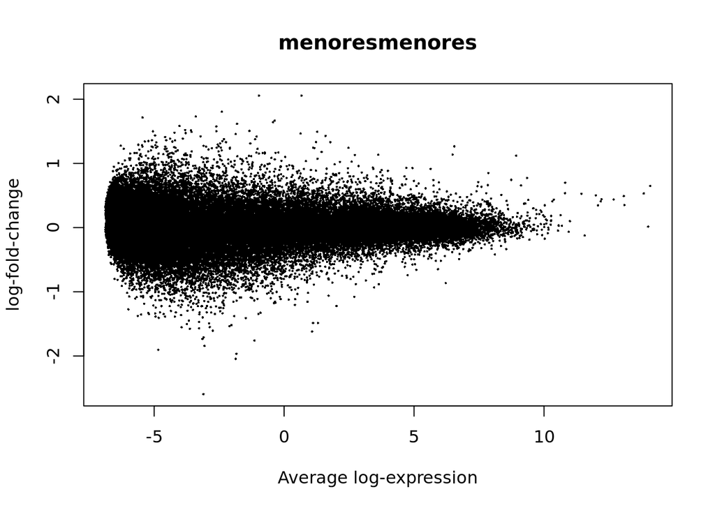

```r
## Visualicemos los resultados estadísticos
plotMA(eb_results, coef = 2)
```

En la parte inferior de la figura 4.A podemos observar que existen algunos pocos genes que se distancian más de la media que el promedio. Para conocer los nombres de esos genes procedmeos a hacer un volcanoplot.

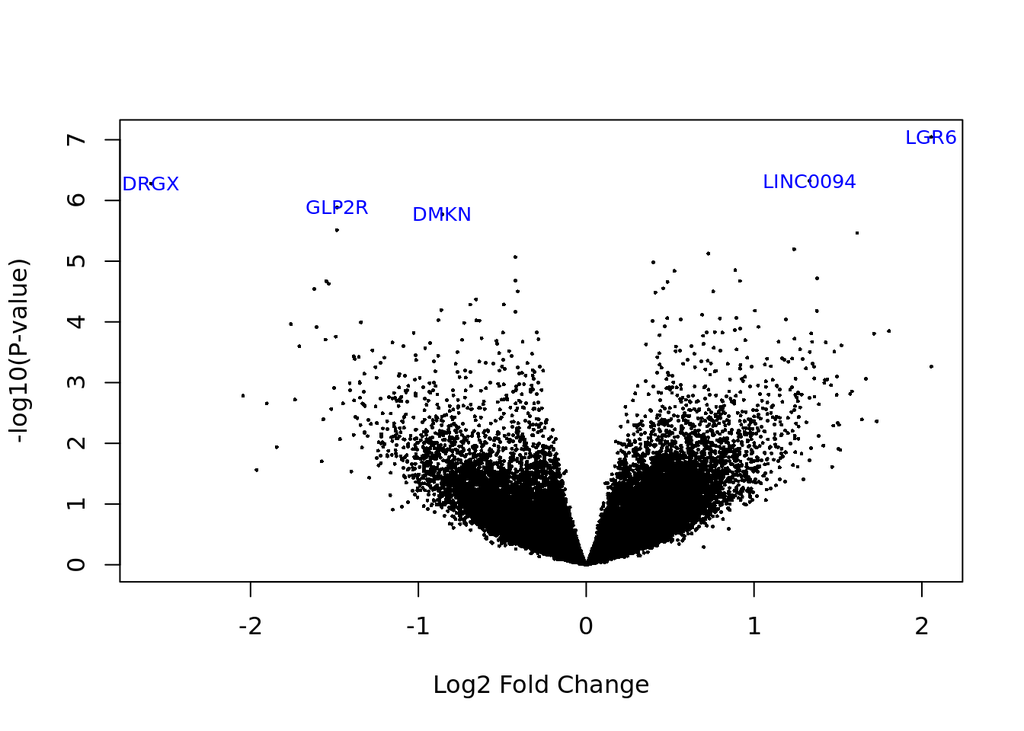

```r
volcanoplot(eb_results, coef = 2, highlight = 5, names = de_results$gene_name)
```

La Figura 4.B nos muestra los nombres de los 5 genes en donde existe un contraste de expresión significativo entre las 2 grupos(menores y mayores).

Obtenemos un poco más de información de esos 5 genes…

```r
#Para visualizar las 6 opciones que tiene LINC0094
#if (interactive()) iSEE::iSEE(rse_gene_SRP132816)<- graficas
```

LINC0094 tiene 6 opciones del 0-5 al final del nombre, así que escogemos una.

```r
de_results[de_results$gene_name %in% c("LGR6", "DRGX", "GLP2R", "DMKN","LINC00945"), ]
```

```
##                    source type score phase            gene_id      gene_type
## ENSG00000133067.17 HAVANA gene  4583    NA ENSG00000133067.17 protein_coding
## ENSG00000165606.8  HAVANA gene  2890    NA  ENSG00000165606.8 protein_coding
## ENSG00000065325.12 HAVANA gene  6052    NA ENSG00000065325.12 protein_coding
## ENSG00000161249.20 HAVANA gene  7444    NA ENSG00000161249.20 protein_coding
## ENSG00000232539.1  HAVANA gene   753    NA  ENSG00000232539.1        lincRNA
##                    gene_name level           havana_gene  tag      logFC
## ENSG00000133067.17      LGR6     1  OTTHUMG00000041383.9 <NA>  2.0555784
## ENSG00000165606.8       DRGX     2  OTTHUMG00000018192.3 <NA> -2.5921479
## ENSG00000065325.12     GLP2R     2 OTTHUMG00000130269.11 <NA> -1.4843527
## ENSG00000161249.20      DMKN     2 OTTHUMG00000048101.17 <NA> -0.8588426
## ENSG00000232539.1  LINC00945     2  OTTHUMG00000065060.1 <NA> -0.6694913
##                       AveExpr         t      P.Value   adj.P.Val         B
## ENSG00000133067.17  0.6725969  6.028065 9.006857e-08 0.004793179  6.455275
## ENSG00000165606.8  -3.1033875 -5.576045 5.270697e-07 0.009349690  4.105926
## ENSG00000065325.12  1.3048411 -5.341213 1.299230e-06 0.017285278  4.774543
## ENSG00000161249.20  1.8567522 -5.272185 1.689784e-06 0.017985045  4.679144
## ENSG00000232539.1  -5.3067644 -1.543555 1.276149e-01 0.826464647 -4.410014
```

Visualización de genes diferencialmente expresados

Figura 5

```r
library("pheatmap")

## Creemos una tabla con información de las muestras
## y con nombres de columnas más amigables
df <- as.data.frame(colData(rse_gene_SRP132816)[, c("menores", "sra_attribute.disease", "sra_attribute.sex", "sra_attribute.tissue")])
colnames(df) <- c("AgeGroup", "disease", "Sex", "Tissue")


nombres_rse_gene <-rowRanges(rse_gene_SRP132816)$gene_name
id_rse_gene <- rowRanges(rse_gene_SRP132816)$gene_id

exprs_heatmap <- vGene$E[rank(de_results$adj.P.Val) <= 10, ]
posiciones <- match(rownames(exprs_heatmap),id_rse_gene)
# hacer un subconjunto de los ronames
filtered_id_names <-rowRanges(rse_gene_SRP132816)$gene_name[posiciones]

# remplazar los nombres de exprs_heatmap
head(exprs_heatmap)
```

```
##                    SRR9264382 SRR9264383 SRR9264384  SRR9264385 SRR9264386
## ENSG00000133067.17 -0.6667385 -0.9567125 -0.5028600 -2.90288080  1.5291939
## ENSG00000165606.8   1.1579776 -0.3179787 -4.7067324 -1.50433142  0.6782721
## ENSG00000189238.5  -0.9346717  0.2233226  0.4225507  0.14548223 -1.0741472
## ENSG00000150893.10  0.5274340 -1.1944040  0.6203390 -0.18572368 -0.6207815
## ENSG00000065325.12  1.3989857  1.3869652  2.4092402 -0.07075797  0.9749474
## ENSG00000130377.13 -2.6424910 -2.5056057 -2.8702311 -2.11438490 -4.2891601
##                     SRR9264387 SRR9264388 SRR9292593 SRR9292594 SRR9292596
## ENSG00000133067.17 -3.14361357  1.2489574  0.5897973   1.889569  2.9413992
## ENSG00000165606.8  -2.98314889  0.5938688 -3.2453919  -2.358358 -3.5873804
## ENSG00000189238.5  -0.07120507 -1.7061167  1.3119848   1.946827  1.3459824
## ENSG00000150893.10  1.15694088 -2.7901810  0.3719921   1.198590  2.8106506
## ENSG00000065325.12 -1.00225772 -0.1211542  2.5689721   3.478421  1.8684034
## ENSG00000130377.13 -5.64611391 -2.7901810 -3.0043838  -2.599366  0.6090168
##                    SRR9292597  SRR9292598 SRR9292599 SRR9292600 SRR9292602
## ENSG00000133067.17  1.4424869  1.47207295   1.354341  0.4151049   2.157779
## ENSG00000165606.8  -3.9449150 -2.60227439  -5.708155 -3.5091678  -3.932711
## ENSG00000189238.5   3.3601695  2.18512593   2.398626  1.7422071   2.151718
## ENSG00000150893.10  1.2192736  2.03267625   2.327103  1.0370252   1.454691
## ENSG00000065325.12  0.3245456  0.03713590   1.068827  3.2199895   3.258524
## ENSG00000130377.13 -0.4854834 -0.03592756  -3.833686 -2.5762820  -1.382514
##                    SRR9292605 SRR9292606 SRR9292607 SRR9292609 SRR9292611
## ENSG00000133067.17  1.0974018  2.3248560   2.675568  0.5774224   1.627281
## ENSG00000165606.8  -4.9396875 -1.2466860  -3.380920 -0.9138257  -3.485419
## ENSG00000189238.5   2.3731955  2.5644806   3.248437  2.3999130   2.454748
## ENSG00000150893.10  0.8240782  2.6094513   2.507147  2.0271389   1.739547
## ENSG00000065325.12  0.3942132  0.3382765   2.052782  2.8954723   2.957525
## ENSG00000130377.13  0.8062669 -0.6440215  -1.421562 -3.1823145  -2.106907
##                    SRR9292612 SRR9292613 SRR9292614 SRR9292615 SRR9292616
## ENSG00000133067.17  0.6641369  4.6920786   3.085757  3.7289736 -0.2404619
## ENSG00000165606.8  -1.6577912 -4.6339013  -4.774295 -4.4075049  2.0692657
## ENSG00000189238.5   1.8366590  3.8699244   3.740090  3.3272047  1.0162310
## ENSG00000150893.10  1.2149044  2.3906843   2.011430  2.2449816  0.3292338
## ENSG00000065325.12  2.2068969 -1.0250921   1.517260  1.2421106  2.4681319
## ENSG00000130377.13 -0.9846016 -0.1356505  -2.111330 -0.2536996 -1.7659234
##                     SRR9292617 SRR9292618 SRR9292619 SRR9292620 SRR9292621
## ENSG00000133067.17  0.19777976 -0.3423286  0.5067624 -0.1608946  0.1278729
## ENSG00000165606.8  -1.43568126 -1.8912219 -0.1947979 -3.6718565 -2.1024248
## ENSG00000189238.5   0.07333239  0.8537365  2.1786605  2.6821725  2.4017067
## ENSG00000150893.10  0.53630437 -0.2031659  0.8124701  1.6428401  2.1337735
```

[output cut: 36 more lines]

```
## ENSG00000130377.13 -1.5843610 -3.5904809 -2.81069911  0.2277540  -1.351233
##                    SRR9262932 SRR9262935  SRR9262936 SRR9262941 SRR9262950
## ENSG00000133067.17  0.4437817 -0.5610972  0.04023237 -0.6027056 -1.6025091
## ENSG00000165606.8  -3.8925017 -2.4270799 -2.44915247 -4.6657154  0.6403475
## ENSG00000189238.5   1.3929005  2.2571597  1.89297919 -0.5542070  2.1511906
## ENSG00000150893.10  1.1164871  2.3208965  0.65346259  0.1342600  0.6671891
## ENSG00000065325.12 -0.3647640  0.9361364  0.12963145  2.0757516  2.7589474
## ENSG00000130377.13 -0.4865093 -5.0593481 -1.02030917 -3.3856074 -2.4505060
##                    SRR9262951 SRR9262953 SRR9262955 SRR9262957
## ENSG00000133067.17  0.7863278  1.2823278  0.2850571  0.9289770
## ENSG00000165606.8  -5.4347759 -6.5694212 -6.3826458 -3.0580839
## ENSG00000189238.5   2.5798026  3.3177994  1.9165622  2.3809059
## ENSG00000150893.10  1.2628867  1.3905807 -0.2602492  1.3276758
## ENSG00000065325.12  1.4107142 -3.3994962  1.6378712 -0.8210447
## ENSG00000130377.13 -1.0702035  0.4418061 -2.6822061  0.4504655
```

```r
exprs_heatmap
```

[output not shown]

[output cut: 88 more lines]

```
## ENSG00000161249.20  2.4306282  2.6753615  2.95980320  2.8295686  3.8921910
## ENSG00000206195.10  1.5950704  2.2893801  1.08242893  2.8855809  3.0128549
## ENSG00000071242.11  4.1796756  4.8020490  4.72718053  4.9434634  5.4062308
## ENSG00000137094.14  4.4488318  4.6386620  3.94448550  4.0152720  4.3271768
##                    SRR9262951 SRR9262953 SRR9262955 SRR9262957
## ENSG00000133067.17  0.7863278  1.2823278  0.2850571  0.9289770
## ENSG00000165606.8  -5.4347759 -6.5694212 -6.3826458 -3.0580839
## ENSG00000189238.5   2.5798026  3.3177994  1.9165622  2.3809059
## ENSG00000150893.10  1.2628867  1.3905807 -0.2602492  1.3276758
## ENSG00000065325.12  1.4107142 -3.3994962  1.6378712 -0.8210447
## ENSG00000130377.13 -1.0702035  0.4418061 -2.6822061  0.4504655
## ENSG00000161249.20  2.2018487  1.7205977  2.2956609  1.4474441
## ENSG00000206195.10  0.7471218 -2.6625306  1.4897726  1.9093482
## ENSG00000071242.11  4.7228237  4.2815470  4.7853994  4.8824744
## ENSG00000137094.14  4.0299741  5.4210374  4.1581280  4.8785540
```

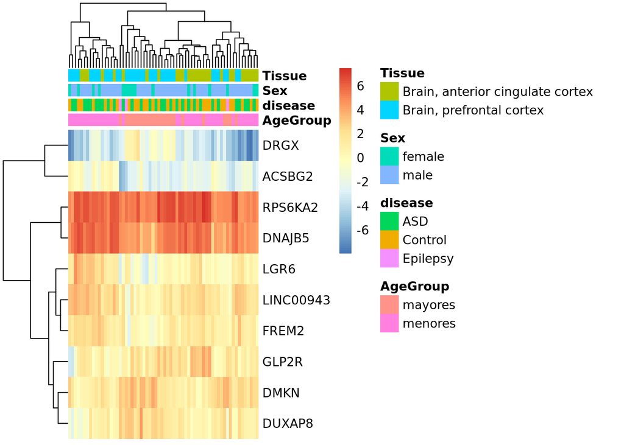

```r
row.names(exprs_heatmap) <- filtered_id_names

pheatmap(
    exprs_heatmap,
    # que agrupe los genes tanto en renglones como en cols que son las muestras
    cluster_rows = TRUE,
    cluster_cols = TRUE,
    show_rownames = TRUE,
    show_colnames = FALSE,
    annotation_col = df
)
```

La Figura 5 es un heatmap donde se mide los niveles de expresion de nuestros 10 genes en relación a distintas categorias. A excepción de los genes “DUXAP8” y “DMKN” los mayores de edad tienen los niveles de expresión estan cerca de la media, ni muy bajos ni muy altos, en contraste a los menores de edad donde los niveles de expresión están más alejados de la media, tanto positiva como negativamente.

```r
# default value of pdf is 4
pdf("Figura5.pdf", height=14, useDingbats = FALSE)
## Y luego podemos cambiar el valor de show_rownames de FALSE a TRUE
pheatmap(
    exprs_heatmap,
    # que agrupe los genes tanto en renglones como en cols que son las muestras
    cluster_rows = TRUE,
    cluster_cols = TRUE,
    show_rownames = TRUE,
    show_colnames = FALSE,
    annotation_col = df
)
dev.off()
```

Figura 6

```r
## Para colores
library("RColorBrewer")

## Convirtiendo los grupos de edad a colores
col.group <- df$AgeGroup
levels(col.group) <- brewer.pal(nlevels(col.group), "Set1")
```

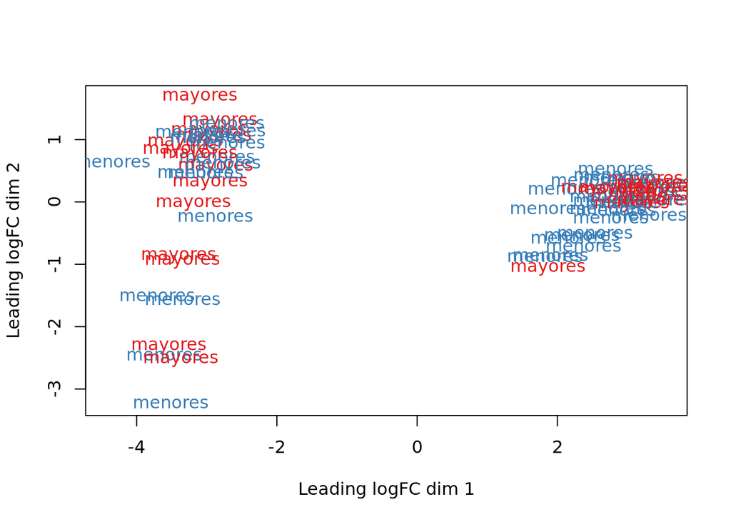

```r
col.group <- as.character(col.group)

## MDS por grupos de edad
plotMDS(vGene$E, labels = df$AgeGroup, col = col.group)
```

```r
## Convirtiendo los valores de Sex a colores
col.sex <- df$Sex
levels(col.sex) <- brewer.pal(nlevels(col.sex), "Dark2")
```

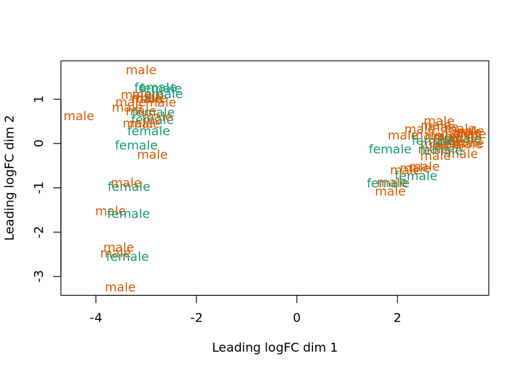

```r
col.sex <- as.character(col.sex)

## MDS por sexo
plotMDS(vGene$E, labels = df$Sex, col = col.sex)
```

```r
## Convirtiendo los valores de Tissue a colores
col.tissue <- df$Tissue
levels(col.tissue) <- brewer.pal(nlevels(col.tissue), "Dark2")
```

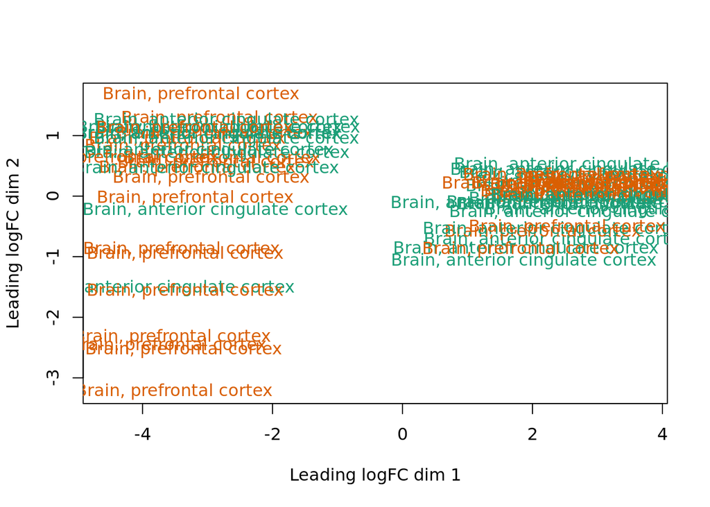

```r
col.tissue <- as.character(col.tissue)

## MDS por sexo
plotMDS(vGene$E, labels = df$Tissue, col = col.tissue)
```

Lamentablemente en la figura 6 en todos sus apartados(edad, sexo y tejido) no se pueden discernir con eficacia grupos separados.